# R Notebook

# Housekeeping

First we set the working directory

```r
dir = "/home/omar/thesis-replication-package/preloads/data_analysis"
```

```r
setwd(dir)
```

Next we import the libraries we need.

```r
library(ggplot2)
library(e1071)
library(dplyr)
library(effsize)
# Import functins we created outselves.
source("util.r")
```

# Getting the data

We load the data and then reshape it a little bit to make it easier to work with.

```r
monsoon_raw_data <- read.csv("../raw_data/Aggregated_Results_Monsoon.csv")
plt_raw_data <- read.csv("../raw_data/http_post_request_payloads.txt")

combined_data = combine_and_reshape_dataframes(monsoon_raw_data, plt_raw_data, "noremovepreload")
intact = combined_data[1:200,]
removed = combined_data[201:400,]
print(combined_data)
```

|  | subject | treatment | run | energy_joules | plt |
| --- | --- | --- | --- | --- | --- |
| 1 | affirm-com | intact | 1 | 32.876551 | 14052 |
| 81 | affirm-com | intact | 2 | 30.363543 | 12295 |
| 161 | affirm-com | intact | 3 | 35.345285 | 15147 |
| 241 | affirm-com | intact | 4 | 34.848865 | 12823 |
| 321 | affirm-com | intact | 5 | 35.033510 | 14853 |
| 3 | africafreak-com | intact | 1 | 15.657237 | 6906 |
| 83 | africafreak-com | intact | 2 | 14.172589 | 6245 |
| 163 | africafreak-com | intact | 3 | 14.067621 | 5837 |
| 243 | africafreak-com | intact | 4 | 15.512016 | 5892 |
| 323 | africafreak-com | intact | 5 | 14.389691 | 5993 |

[output cut: 390 more lines]

```r
print(intact)
```

|  | subject | treatment | run | energy_joules | plt |
| --- | --- | --- | --- | --- | --- |
| 1 | affirm-com | intact | 1 | 32.876551 | 14052 |
| 81 | affirm-com | intact | 2 | 30.363543 | 12295 |
| 161 | affirm-com | intact | 3 | 35.345285 | 15147 |
| 241 | affirm-com | intact | 4 | 34.848865 | 12823 |
| 321 | affirm-com | intact | 5 | 35.033510 | 14853 |
| 3 | africafreak-com | intact | 1 | 15.657237 | 6906 |
| 83 | africafreak-com | intact | 2 | 14.172589 | 6245 |
| 163 | africafreak-com | intact | 3 | 14.067621 | 5837 |
| 243 | africafreak-com | intact | 4 | 15.512016 | 5892 |
| 323 | africafreak-com | intact | 5 | 14.389691 | 5993 |

[output cut: 190 more lines]

```r
print(removed)
```

|  | subject | treatment | run | energy_joules | plt |
| --- | --- | --- | --- | --- | --- |
| 2 | affirm-com | removed | 1 | 32.895518 | 13040 |
| 82 | affirm-com | removed | 2 | 28.581027 | 11855 |
| 162 | affirm-com | removed | 3 | 30.544055 | 12516 |
| 242 | affirm-com | removed | 4 | 36.744965 | 15092 |
| 322 | affirm-com | removed | 5 | 30.834266 | 12050 |
| 4 | africafreak-com | removed | 1 | 14.011721 | 6201 |
| 84 | africafreak-com | removed | 2 | 14.472573 | 5810 |
| 164 | africafreak-com | removed | 3 | 15.599276 | 6472 |
| 244 | africafreak-com | removed | 4 | 13.179360 | 7420 |
| 324 | africafreak-com | removed | 5 | 15.918159 | 7483 |

[output cut: 190 more lines]

# Data Exploration

First lets get some summaries of the data..

```r
print("All")
```

```
[1] "All"
```

```r
summary(combined_data$plt)
```

```
   Min. 1st Qu.  Median    Mean 3rd Qu.    Max.
   2528    6214    8461   12159   12758   57452
```

```r
sd(combined_data$plt)
```

```
[1] 10927.81
```

```r
print("Intact")
```

```
[1] "Intact"
```

```r
summary(intact$plt)
```

```
   Min. 1st Qu.  Median    Mean 3rd Qu.    Max.
   2528    6240    8562   12057   13458   57031
```

```r
sd(intact$plt)
```

```
[1] 10629.48
```

```r
print("Removed")
```

```
[1] "Removed"
```

```r
summary(removed$plt)
```

```
   Min. 1st Qu.  Median    Mean 3rd Qu.    Max.
   2586    6190    8014   12260   12556   57452
```

```r
sd(removed$plt)
```

```
[1] 11244.01
```

Then we make a boxplot of the data.

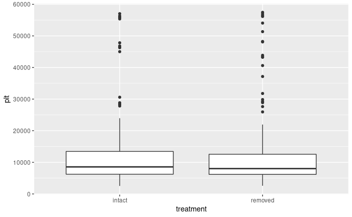

```r
ggplot(combined_data, aes(x=treatment, y=plt)) +
  geom_boxplot()
```

We can see that the data is very close.

Lets inspect the outliers..

```r
outliers <- boxplot.stats(combined_data$plt)$out
out_ind <- which(combined_data$plt %in% c(outliers))
outliers <- combined_data[out_ind,]
print(outliers)
```

|  | subject | treatment | run | energy_joules | plt |
| --- | --- | --- | --- | --- | --- |
| 5 | agriwebb-com | intact | 1 | 38.21901 | 30596 |
| 85 | agriwebb-com | intact | 2 | 37.64526 | 28436 |
| 165 | agriwebb-com | intact | 3 | 38.43777 | 28291 |
| 245 | agriwebb-com | intact | 4 | 39.45466 | 28850 |
| 325 | agriwebb-com | intact | 5 | 38.76181 | 27826 |
| 23 | fastcodesign-com | intact | 1 | 87.55365 | 46815 |
| 103 | fastcodesign-com | intact | 2 | 85.66310 | 46441 |
| 183 | fastcodesign-com | intact | 3 | 86.05196 | 47819 |
| 263 | fastcodesign-com | intact | 4 | 87.59769 | 45018 |
| 343 | fastcodesign-com | intact | 5 | 87.37787 | 46269 |

[output cut: 25 more lines]

```r
outliers %>% group_by(subject, treatment) %>% summarise(Count=n())
```

| subject | treatment | Count |
| --- | --- | --- |
| agriwebb-com | intact | 5 |
| agriwebb-com | removed | 5 |
| fastcodesign-com | intact | 5 |
| fastcodesign-com | removed | 5 |
| ict-moscow | removed | 1 |
| newsbreak-com | removed | 1 |
| schmoozecom-com | removed | 1 |
| scmp-com | intact | 5 |
| scmp-com | removed | 5 |
| unilad-co | intact | 1 |

[output cut: 1 more lines]

We see that most of the outliers are all for the same mobile web apps so we decide to not remove them. This is also to be expected as each mobile web app differs from the others in terms of size, logic etc.

# Testing for normality

The paired t-test assumes that the differences between pairs are normally distributed. Lets investigate..

```r
differences <- NULL
differences$subject <- intact$subject
differences$diff <-  removed$plt - intact$plt
differences <- data.frame(differences$subject, differences$diff)
differences <- differences %>%
  rename(
   subject = "differences.subject",
    diff = differences.diff
    )
print(differences)
```

| subject | diff |
| --- | --- |
| affirm-com | -1012 |
| affirm-com | -440 |
| affirm-com | -2631 |
| affirm-com | 2269 |
| affirm-com | -2803 |
| africafreak-com | -705 |
| africafreak-com | -435 |
| africafreak-com | 635 |
| africafreak-com | 1528 |
| africafreak-com | 1490 |

[output cut: 190 more lines]

```r
summary(differences$diff)
```

```
    Min.  1st Qu.   Median     Mean  3rd Qu.     Max.
-11776.0   -940.8   -106.5    202.8    656.2  44233.0
```

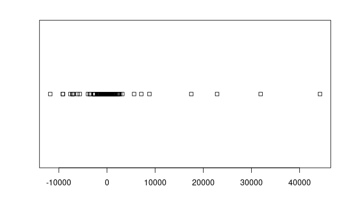

```r
stripchart(differences$diff)
```

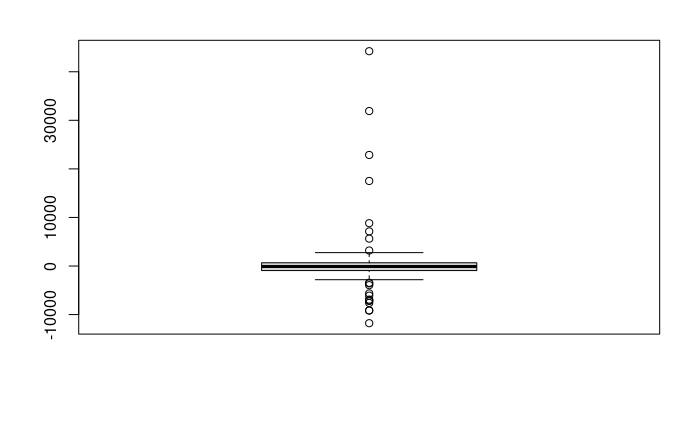

```r
boxplot(differences$diff)
```

```r
outliers <- boxplot.stats(differences$diff)$out
out_ind <- which(differences$diff %in% c(outliers))
differences[out_ind,]
```

|  | subject | diff |
| --- | --- | --- |
| 11 | agriwebb-com | 17508 |
| 24 | beegru-com | -3945 |
| 43 | cbc-ca | -6918 |
| 44 | cbc-ca | 5637 |
| 56 | fastcodesign-com | -3577 |
| 60 | fastcodesign-com | -5647 |
| 82 | ict-moscow | 22865 |
| 88 | infobunny-com | -9175 |
| 89 | infobunny-com | -11776 |
| 108 | ladbible-com | -7197 |

[output cut: 10 more lines]

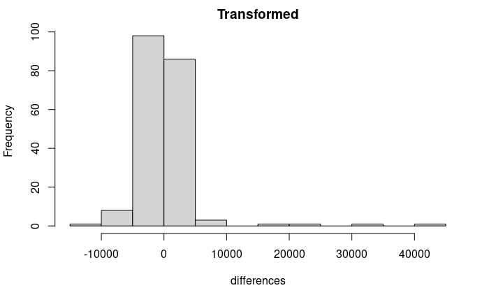

```
[1] "Transformed:  none"

    Shapiro-Wilk normality test

data:  differences
W = 0.47245, p-value < 2.2e-16

[1] "Skewness after transformation 5.42023426291518"
```

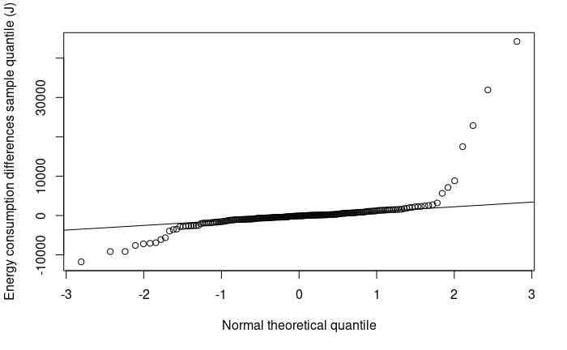

```r
transform_and_test(removed$plt, intact$plt)
```

Since the differences are not normally distributed we apply several transformations to see if we can approach a normal distribution.

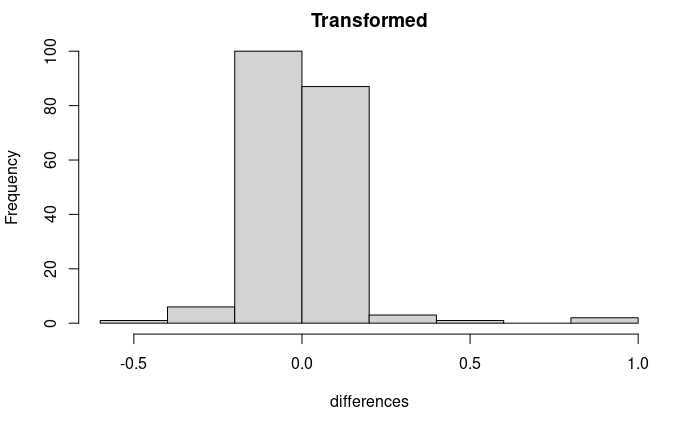

```
[1] "Transformed:  log"

    Shapiro-Wilk normality test

data:  differences
W = 0.72381, p-value < 2.2e-16

[1] "Skewness after transformation 2.83656259981479"
```

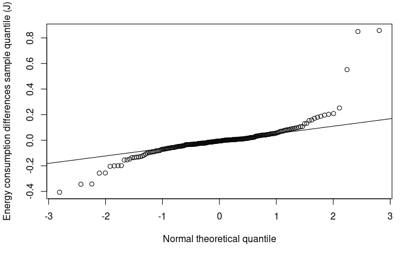

```r
transform_and_test(removed$plt, intact$plt, "log")
```

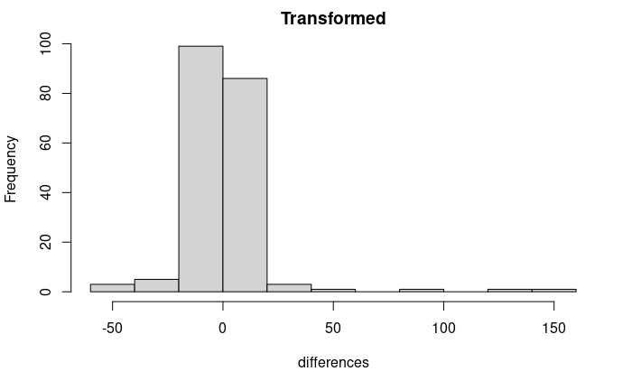

```
[1] "Transformed:  sqrt"

    Shapiro-Wilk normality test

data:  differences
W = 0.59251, p-value < 2.2e-16

[1] "Skewness after transformation 4.17054890986791"
```

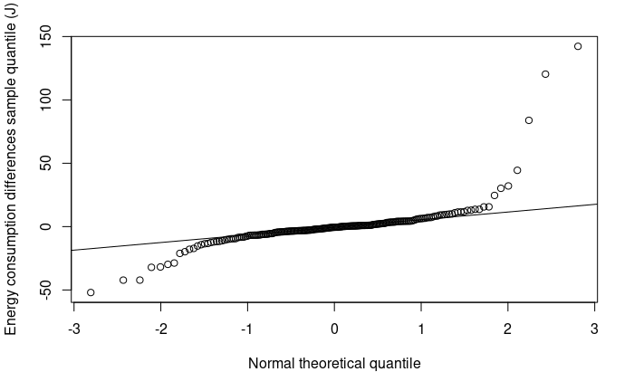

```r
transform_and_test(removed$plt, intact$plt, "sqrt")
```

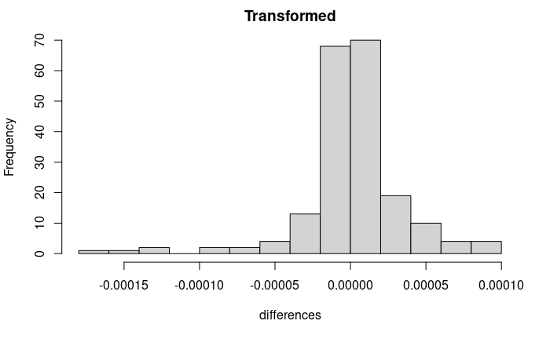

```
[1] "Transformed:  recip"

    Shapiro-Wilk normality test

data:  differences
W = 0.84448, p-value = 2.337e-13

[1] "Skewness after transformation -1.36690310042693"
```

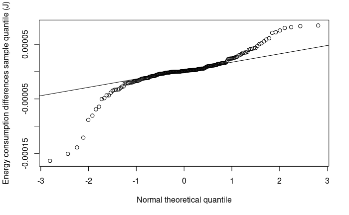

```r
transform_and_test(removed$plt, intact$plt, "recip")
```

We can see that for all three transformations the data is not normally distributed.

# Hypothesis Testing

Since the data is not normally distributed we will use the Wilcoxon signed rank test:

```r
wilcox.test(removed$plt, intact$plt, paired=TRUE)
```

```
    Wilcoxon signed rank test with continuity correction

data:  removed$plt and intact$plt
V = 8806, p-value = 0.1292
alternative hypothesis: true location shift is not equal to 0
```

As we can see this tests gives a p-value of 0.1292 which is above our 0.05 treshold and thus we cannot reject the null hypothesis. So we are not able to claim that there is a significant difference in PLT between MWP that use resource preloading or not.

# Effect Size Estimation

```r
cliffs_delta_plt <- cliff.delta(removed$plt, intact$plt)
print(cliffs_delta_plt)
```

```
Cliff's Delta

delta estimate: -0.0115 (negligible)
95 percent confidence interval:
     lower      upper
-0.1243287  0.1016223
```

As expected the value of the Cliff’s delta measure is negligible.